# 19 - Large Language Models: The Basics

Biostatistics 735 — Machine Learning in Public Health

Author

Alexander McLain

Published

November 10, 2026

These notes go with the *Large Language Models: The Basics* slides. We can’t train an LLM in a class example (GPT-3 took months on thousands of GPUs). Instead, we build each piece in miniature with ordinary R code:

1. a **language model** that predicts the next word by counting (an $n$-gram model),
2. a **tokenizer** (byte-pair encoding),
3. **word embeddings** from a word-by-word count matrix and an SVD,
4. **attention**, computed by hand with small matrices,
5. **temperature** and sampling, and
6. **evaluating** an LLM used as a classifier.

Our text throughout is Jane Austen’s novels, from the `janeaustenr` package.

# 1 A language model is a classifier

A language model gives the probability of the next word given the words before it. In other words, it is a classification model where the outcome is the next word and there are $K$ classes, one for every word in the vocabulary.

## 1.1 The data

We’ll start with *Pride and Prejudice*. `unnest_tokens()` splits text into words, makes everything lower case, and drops punctuation.

```r
pp_words <- tibble(text = paste(prideprejudice, collapse = " ")) |>
  unnest_tokens(word, text) |>
  pull(word)

length(pp_words)          # number of words in the book
```

```
[1] 122204
```

```r
length(unique(pp_words))  # size of the vocabulary, K
```

```
[1] 6538
```

```r
head(pp_words, 20)
```

```
 [1] "pride"        "and"          "prejudice"    "by"           "jane"
 [6] "austen"       "chapter"      "1"            "it"           "is"
[11] "a"            "truth"        "universally"  "acknowledged" "that"
[16] "a"            "single"       "man"          "in"           "possession"
```

So the “classification problem” has about $K = 6{,}500$ classes.

## 1.2 A bigram model

The simplest language model is the **bigram model**: the next word depends only on the previous word. The estimate is just counting:

$$\hat{P}(w_t \mid w_{t-1}) = \frac{\#(w_{t-1}, w_t)}{\#(w_{t-1})}.$$

This is the MLE of a multinomial distribution, one for each previous word.

```r
bigrams <- tibble(prev = head(pp_words, -1),   # word t-1
                  nxt  = pp_words[-1]) |>       # word t
  count(prev, nxt) |>
  group_by(prev) |>
  mutate(prob = n / sum(n)) |>
  ungroup()

# The k most likely next words after word w
next_word <- function(w, k = 5) {
  bigrams |> filter(prev == w) |> slice_max(prob, n = k, with_ties = FALSE)
}

next_word("miss")   |> kbl2(digits = 3)
```

| prev | nxt | n | prob |
| --- | --- | --- | --- |
| miss | bingley | 72 | 0.254 |
| miss | bennet | 60 | 0.212 |
| miss | darcy | 34 | 0.120 |
| miss | lucas | 23 | 0.081 |
| miss | de | 20 | 0.071 |

```r
next_word("dear")   |> kbl2(digits = 3)
```

| prev | nxt | n | prob |
| --- | --- | --- | --- |
| dear | lizzy | 15 | 0.095 |
| dear | sir | 10 | 0.063 |
| dear | aunt | 8 | 0.051 |
| dear | jane | 7 | 0.044 |
| dear | dear | 6 | 0.038 |

This is the same table as the “type 2 ____” example on the slides, just from a much smaller model.

## 1.3 The problems with counting

How many of the possible word pairs did we actually see?

```r
K <- length(unique(pp_words))
c(possible_pairs = K^2,
  observed_pairs = nrow(bigrams),
  percent_seen   = 100 * nrow(bigrams) / K^2)
```

```
possible_pairs observed_pairs   percent_seen
  4.274544e+07   5.499800e+04   1.286640e-01
```

Only about 0.1% of the possible pairs ever occur, so almost every estimated probability is zero. That is a problem when we use the model on new text. Let’s take the fitted model to another Austen book, *Sense and Sensibility*, and check how many of its word pairs were never seen in *Pride and Prejudice*:

```r
ss_words <- tibble(text = paste(sensesensibility, collapse = " ")) |>
  unnest_tokens(word, text) |>
  pull(word)

ss_pairs <- tibble(prev = head(ss_words, -1), nxt = ss_words[-1]) |>
  left_join(bigrams, by = c("prev", "nxt"))

mean(is.na(ss_pairs$prob))   # share of pairs with estimated probability 0
```

```
[1] 0.3968122
```

About 40% of the word pairs in the new book get probability zero, so the cross-entropy loss, $-\sum_t \log \hat{P}(w_t \mid w_{t-1})$, is infinite. The model is badly **overfit** to the training book. The model also has no idea that “happy” and “glad” are similar, and it ignores everything except the previous word. Neural language models fix these problems with embeddings (Section 3) and attention (Section 4).

## 1.4 Generating text

To generate text we repeat four steps: get the next-word probabilities, sample a word, add it to the text, and repeat. This is exactly how an LLM writes, one token at a time.

```r
generate <- function(start, n_words = 15) {
  out <- start
  for (i in 1:n_words) {
    choices <- bigrams |> filter(prev == tail(out, 1))
    out <- c(out, sample(choices$nxt, size = 1, prob = choices$prob))
  }
  paste(out, collapse = " ")
}

set.seed(735)
generate("elizabeth")
```

```
[1] "elizabeth did not hear herself she likes your estimation you give me i always moving wrong"
```

```r
generate("elizabeth")
```

```
[1] "elizabeth was elegant female of that by imitation elizabeth colouring i hope mr bennet was alone"
```

```r
generate("elizabeth")
```

```
[1] "elizabeth that time between us of his cruelty towards mr bingley not make her nieces of"
```

The same starting word gives a different answer each time, because the next word is **sampled**. Each pair of words looks reasonable, but the sentences make no sense, because the model only sees one word back. We return to sampling in Section 5.

# 2 Tokenization

LLMs don’t use whole words. They use **subword tokens**: common words are one token and rare words are split into pieces. Here are the three options for one sentence.

```r
sentence <- "The patient was diagnosed with hypercholesterolemia"

# Characters
strsplit(tolower(sentence), "")[[1]]
```

```
 [1] "t" "h" "e" " " "p" "a" "t" "i" "e" "n" "t" " " "w" "a" "s" " " "d" "i" "a"
[20] "g" "n" "o" "s" "e" "d" " " "w" "i" "t" "h" " " "h" "y" "p" "e" "r" "c" "h"
[39] "o" "l" "e" "s" "t" "e" "r" "o" "l" "e" "m" "i" "a"
```

```r
# Words
strsplit(tolower(sentence), " ")[[1]]
```

```
[1] "the"                  "patient"              "was"
[4] "diagnosed"            "with"                 "hypercholesterolemia"
```

Characters give a tiny vocabulary but very long sequences. Words give short sequences but a huge vocabulary, and any word not seen in training (e.g., “COVID-19” in 2019) is unknown. Subwords are in between.

## 2.1 Byte-pair encoding (BPE) from scratch

BPE (Sennrich et al., 2016) learns subword tokens from data:

1. Start with each word split into single characters (plus an end-of-word marker, `_`).
2. Count every pair of adjacent symbols, across all words.
3. Merge the most frequent pair into one new symbol.
4. Repeat steps 2–3 a set number of times.

We’ll use a tiny made-up corpus: the word “low” appears 5 times, “lower” 2 times, and so on.

```r
corpus <- c(low = 5, lower = 2, newest = 6, widest = 3)

# Each word as a vector of symbols
splits <- lapply(names(corpus), function(w) c(strsplit(w, "")[[1]], "_"))
names(splits) <- names(corpus)
splits$low
```

```
[1] "l" "o" "w" "_"
```

```r
splits$newest
```

```
[1] "n" "e" "w" "e" "s" "t" "_"
```

Two small functions: one counts adjacent pairs (weighted by how often the word appears), and one merges a pair everywhere it occurs in a word.

```r
count_pairs <- function(splits, freq) {
  map2_dfr(splits, freq, function(s, f)
    tibble(left = head(s, -1), right = s[-1], n = f)) |>
    count(left, right, wt = n, sort = TRUE)
}

merge_pair <- function(s, a, b) {
  out <- character(0)
  i <- 1
  while (i <= length(s)) {
    if (i < length(s) && s[i] == a && s[i + 1] == b) {
      out <- c(out, paste0(a, b))   # merge the pair
      i <- i + 2
    } else {
      out <- c(out, s[i])
      i <- i + 1
    }
  }
  out
}

count_pairs(splits, corpus) |> head(5) |> kbl2()
```

| left | right | n |
| --- | --- | --- |
| e | s | 9 |
| s | t | 9 |
| t | _ | 9 |
| w | e | 8 |
| l | o | 7 |

The most common pair is “e” followed by “s” (in “newest” and “widest”: $6 + 3 = 9$ times), so that is the first merge. Now we run 8 merges.

```r
merges <- tibble(step = integer(), left = character(), right = character(), n = numeric())

for (step in 1:8) {
  top <- count_pairs(splits, corpus) |> slice(1)
  merges <- bind_rows(merges, tibble(step = step, left = top$left,
                                     right = top$right, n = top$n))
  splits <- lapply(splits, merge_pair, a = top$left, b = top$right)
}

merges |> mutate(new_token = paste0(left, right)) |> kbl2()
```

| step | left | right | n | new_token |
| --- | --- | --- | --- | --- |
| 1 | e | s | 9 | es |
| 2 | es | t | 9 | est |
| 3 | est | _ | 9 | est_ |
| 4 | l | o | 7 | lo |
| 5 | lo | w | 7 | low |
| 6 | e | w | 6 | ew |
| 7 | ew | est_ | 6 | ewest_ |
| 8 | n | ewest_ | 6 | newest_ |

```r
# How each word is tokenized now
sapply(splits, paste, collapse = " | ")
```

```
               low              lower             newest             widest
         "low | _"  "low | e | r | _"          "newest_" "w | i | d | est_"
```

The common word “newest” became a single token. Words share pieces like “est_” and “low”. To tokenize a new word, apply the learned merges in the same order:

```r
tokenize <- function(word, merges) {
  s <- c(strsplit(word, "")[[1]], "_")
  for (m in seq_len(nrow(merges))) s <- merge_pair(s, merges$left[m], merges$right[m])
  s
}

tokenize("lowest", merges)   # never seen, but built from known pieces
```

```
[1] "low"  "est_"
```

```r
tokenize("slow", merges)
```

```
[1] "s"   "low" "_"
```

“lowest” never appeared in the corpus, but it is still tokenized using known pieces. Real tokenizers do the same thing with tens of thousands of merges learned from a huge amount of text. You can try GPT’s tokenizer at https://platform.openai.com/tokenizer; notice how medical terms and non-English words get split into many tokens.

## 2.2 Tokens and cost

A rule of thumb is that 1 token is about 3/4 of an English word. So *Pride and Prejudice* is roughly

```r
round(length(pp_words) / 0.75)
```

```
[1] 162939
```

tokens. LLM prices and context-window limits are measured in tokens, so this is how you estimate the cost of a project (e.g., coding 50,000 survey responses).

# 3 Embeddings

## 3.1 One-hot encoding

A one-hot vector for word $k$ is all zeros except a 1 in position $k$. Every pair of different words has cosine similarity 0, so “fever” is as far from “pyrexia” as from “bicycle”.

```r
cosine <- function(a, b) sum(a * b) / sqrt(sum(a^2) * sum(b^2))

one_hot <- diag(3)
rownames(one_hot) <- c("fever", "pyrexia", "bicycle")
one_hot
```

```
        [,1] [,2] [,3]
fever      1    0    0
pyrexia    0    1    0
bicycle    0    0    1
```

```r
cosine(one_hot["fever", ], one_hot["pyrexia", ])
```

```
[1] 0
```

```r
cosine(one_hot["fever", ], one_hot["bicycle", ])
```

```
[1] 0
```

An **embedding** replaces this with a short, dense vector, so that similar words have similar vectors. Here are the made-up numbers from the slides:

```r
emb_toy <- rbind(fever   = c(0.82, -0.11, 0.45, 0.30),
                 pyrexia = c(0.79, -0.05, 0.41, 0.36),
                 bicycle = c(-0.20, 0.91, -0.33, 0.02))

cosine(emb_toy["fever", ], emb_toy["pyrexia", ])
```

```
[1] 0.9952806
```

```r
cosine(emb_toy["fever", ], emb_toy["bicycle", ])
```

```
[1] -0.4160868
```

## 3.2 Building embeddings from Jane Austen

Where do the numbers come from? The idea is that **words used in similar contexts have similar meanings**. We’ll build embeddings in three steps:

1. **Count** how often each pair of words appears within 4 words of each other (a $K \times K$ co-occurrence matrix).
2. **Reweight** the counts so that we measure whether two words appear together *more than expected by chance* (positive pointwise mutual information, PPMI).
3. **Reduce** the $K$-dimensional rows to $d = 100$ dimensions with an SVD, the same calculation as PCA.

LLMs learn their embeddings differently (as the first layer of the network, trained to predict the next token), but the result is similar: a short vector per word.

### 3.2.1 Step 1: count co-occurrences

```r
tok <- austen_books() |>
  group_by(book) |>
  summarise(text = paste(text, collapse = " ")) |>
  unnest_tokens(word, text)

vocab <- tok |> count(word, sort = TRUE) |> filter(n >= 10) |> slice_head(n = 6000)
tok <- tok |> mutate(id = match(word, vocab$word))  # NA for rare words
V <- nrow(vocab)

# All pairs of words that are 1, 2, 3, or 4 words apart (within a book)
pairs <- map_dfr(1:4, function(k)
  tok |> group_by(book) |> transmute(a = id, b = lead(id, k)) |> ungroup()) |>
  filter(!is.na(a), !is.na(b))

# Co-occurrence matrix (symmetric). sparseMatrix adds up repeated (i, j) pairs.
C <- sparseMatrix(i = c(pairs$a, pairs$b), j = c(pairs$b, pairs$a), x = 1, dims = c(V, V))
dimnames(C) <- list(vocab$word, vocab$word)

C[c("sister", "brother", "letter"), c("dear", "my", "her", "write", "read")]
```

```
3 x 5 sparse Matrix of class "dgCMatrix"
        dear  my her write read
sister    25 108 356     3    1
brother   10  73 156     1    1
letter     4  20  79    12   16
```

### 3.2.2 Step 2: reweight with PPMI

Common words like “the” and “her” co-occur with everything, so raw counts mostly measure how common a word is. Pointwise mutual information compares the observed co-occurrence with what we’d expect if the two words were independent:

$$\text{PMI}(a, b) = \log \frac{P(a, b)}{P(a)\,P(b)}.$$

PMI $> 0$ means the words appear together more than by chance. We set negative values to 0 (that’s the “positive” in PPMI). Raising the column totals to the power 0.75 is a standard adjustment (Levy et al., 2015) that keeps very rare words from getting huge PMI values.

```r
tot <- sum(C)
p_a <- rowSums(C) / tot
p_b <- colSums(C)^0.75
p_b <- p_b / sum(p_b)

S <- summary(C)   # the non-zero entries: row i, column j, count x
pmi <- log((S$x / tot) / (p_a[S$i] * p_b[S$j]))
P <- sparseMatrix(i = S$i, j = S$j, x = pmax(pmi, 0), dims = c(V, V))

set.seed(98302)
rand_words <- sort(sample(1:nrow(P),5))
colnames(C)[rand_words]
```

```
[1] "he"          "surprised"   "admire"      "approbation" "delays"
```

```r
P[rand_words,rand_words]
```

```
5 x 5 sparse Matrix of class "dgCMatrix"

[1,] 0.6844238 0.000000 0 0 .
[2,] 0.6512216 2.872451 . . .
[3,] 0.3329788 .        . . .
[4,] 0.3651359 .        . . .
[5,] .         .        . . .
```

The diagonal of `P` is a “self-association” score. It is 0 for words that repeat no more often than chance (most common words like “the” and “her”, whose negative PMI gets cut to 0). It is large for words that really do come in bursts (“ha”, “no”, “very”, exclamations, and some names in dialogue). Note that the diagonal is inflated by a factor of 2 (on the log scale) relative to the off-diagonal.

### 3.2.3 Step 3: reduce with an SVD

`irlba()` computes the first 100 singular vectors of the sparse $4{,}000 \times 4{,}000$ matrix. Each word’s embedding is its row of $\mathbf{U}\mathbf{D}^{1/2}$. Finally, we scale every embedding to length 1, so the cosine similarity is just a dot product.

```r
set.seed(1)
sv <- irlba(P, nv = 100)
E <- sv$u %*% diag(sqrt(sv$d))
rownames(E) <- vocab$word
E <- E / sqrt(rowSums(E^2))

dim(E)          # 4,000 words, each a vector of length 100
```

```
[1] 4008  100
```

```r
E["sister", 1:8]
```

```
[1]  0.35395813 -0.07883399 -0.12033141 -0.36155837 -0.06759500 -0.01095776
[7]  0.13423031 -0.22883418
```

```r
sum(E["sister",]^2)
```

```
[1] 1
```

`E["sister",]` is the 100 number summary of `P["sister",]` the PPMI between “sister” and every word in the vocabulary.

SVD is similar to PCA. From the SVD, $\mathbf{P}\mathbf{V} = \mathbf{U}\mathbf{D}$ However, there are two differences:

- **The power on D.** PCA scores use $\mathbf{U}\mathbf{D}$. Here we use $\mathbf{U}\mathbf{D}^{1/2}$, which splits $\mathbf{D}$ evenly between words and contexts: $\mathbf{P} \approx (\mathbf{U}\mathbf{D}^{1/2})(\mathbf{V}\mathbf{D}^{1/2})^\top$. The dot product of a word’s embedding with a context word’s vector then approximates their PPMI. Levy, Goldberg & Dagan (2015) found that downweighting $\mathbf{D}$ like this usually gives better word similarities.
- **No centering.** `P` is not centered before the SVD, unlike `prcomp.`

The SVD splits P into a product of two matrices, one with a row per word and one with a row per context word. Each entry of P is then a dot product of one row from each.

**The algebra.** Write out a single entry of the rank-100 approximation of the PPMI:

$$P_{ab} \approx \sum_{k=1}^{100} u_{ak}, d_k, v_{bk}.$$

Split each $d_k$ into $\sqrt{d_k}\cdot\sqrt{d_k}$ and give one half to each side:

$$P_{ab} \approx \sum_{k=1}^{100} \left(\sqrt{d_k},u_{ak}\right)\left(\sqrt{d_k},v_{bk}\right) = \mathbf{w}_a^\top \mathbf{c}_b,$$

where

- $\mathbf{w}_a$ = row $a$ of $\mathbf{U}\mathbf{D}^{1/2}$, the word vector for $a$ (our raw embedding), and
- $\mathbf{c}_b$ = row $b$ of $\mathbf{V}\mathbf{D}^{1/2}$, the context vector for $b$.

```r
W  <- sv$u %*% diag(sqrt(sv$d))   # word vectors (before scaling to length 1)
Cv <- sv$v %*% diag(sqrt(sv$d))   # context vectors
rownames(W) <- rownames(Cv) <- vocab$word

pick <- c("sister", "letter", "morning")
ctx  <- c("dear", "my", "write", "read", "evening")

round(W[pick, ] %*% t(Cv[ctx, ]), 2)                          # dot products
```

```
        dear   my write read evening
sister  0.73 1.48  0.20 0.16   -0.05
letter  0.37 1.17  0.71 1.20    0.21
morning 0.20 0.23  0.16 0.14    1.53
```

```r
round(as.matrix(P[match(pick, vocab$word), match(ctx, vocab$word)]), 2)  # PPMI
```

```
     [,1] [,2] [,3] [,4] [,5]
[1,] 1.32 1.76 0.50 0.00 0.00
[2,] 0.00 0.56 2.37 2.38 0.00
[3,] 0.00 0.50 0.00 0.00 0.74
```

## 3.3 Nearest neighbors

Since every row of `E` has length 1, `E %*% E[w, ]` gives the cosine similarity between word `w` and every other word.

```r
nearest <- function(w, k = 5) {
  s <- drop(E %*% E[w, ])
  s <- sort(s, decreasing = TRUE)[-1]   # drop the word itself
  tibble(word = w, neighbor = names(s)[1:k], cosine = s[1:k])
}

map_dfr(c("sister", "morning", "letter", "happy"), nearest, k = 4) |>
  kbl2(digits = 2)
```

| word | neighbor | cosine |
| --- | --- | --- |
| sister | brother | 0.78 |
| sister | mother | 0.76 |
| sister | father | 0.75 |
| sister | friend | 0.61 |
| morning | day | 0.82 |
| morning | next | 0.78 |
| morning | evening | 0.75 |
| morning | last | 0.69 |
| letter | note | 0.69 |
| letter | read | 0.60 |
| letter | letters | 0.58 |
| letter | writing | 0.55 |
| happy | now | 0.53 |
| happy | love | 0.52 |
| happy | most | 0.50 |
| happy | glad | 0.49 |

Nobody told the method that “sister” and “brother” are both family members. It learned that from how the words are used.

**Try it:** look up some other words, e.g. `nearest("ball")`, `nearest("walk")`, or `nearest("rich")`. Which neighbors make sense? Which are odd, and why might that be in Austen’s writing?

## 3.4 Plotting the embeddings

We can’t plot 100 dimensions, so we use PCA (on a few groups of words) to get two dimensions, as on the slides.

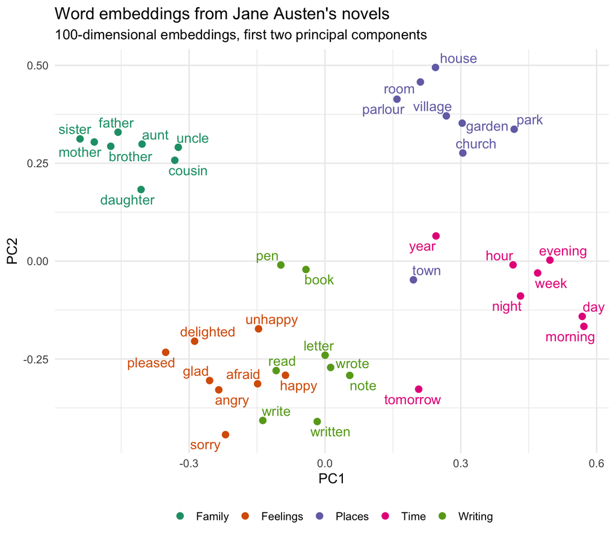

```r
groups <- list(
  Family   = c("sister", "brother", "mother", "father", "aunt", "uncle", "daughter", "cousin"),
  Time     = c("morning", "evening", "night", "day", "week", "tomorrow", "hour", "year"),
  Places   = c("house", "room", "park", "garden", "church", "village", "town", "parlour"),
  Writing  = c("letter", "note", "read", "write", "written", "book", "wrote", "pen"),
  Feelings = c("happy", "glad", "pleased", "sorry", "delighted", "unhappy", "afraid", "angry")
)
sel <- enframe(groups, "group", "word") |> unnest(word)

pc <- prcomp(E[sel$word, ])
sel <- sel |> mutate(PC1 = pc$x[, 1], PC2 = pc$x[, 2])

ggplot(sel, aes(PC1, PC2, color = group, label = word)) +
  geom_point(size = 2.5) +
  geom_text_repel(size = 4.5, show.legend = FALSE, seed = 1) +
  scale_color_brewer(palette = "Dark2") +
  labs(color = NULL, title = "Word embeddings from Jane Austen's novels",
       subtitle = "100-dimensional embeddings, first two principal components") +
  theme(legend.position = "bottom")
```

The groups mostly separate, even though only two of the 100 dimensions are shown.

## 3.5 Embeddings as features

Once each word is a vector, we can make a vector for a whole document, for example by averaging the embeddings of its words. Then the methods we already know (penalized regression, random forests, clustering) can use the document vectors as features. We’ll do this with real public health text in the NLP applications notes.

Here is a quick example: one vector per **chapter** (the average of its word embeddings, leaving out stop words like “the” and “of”), followed by PCA.

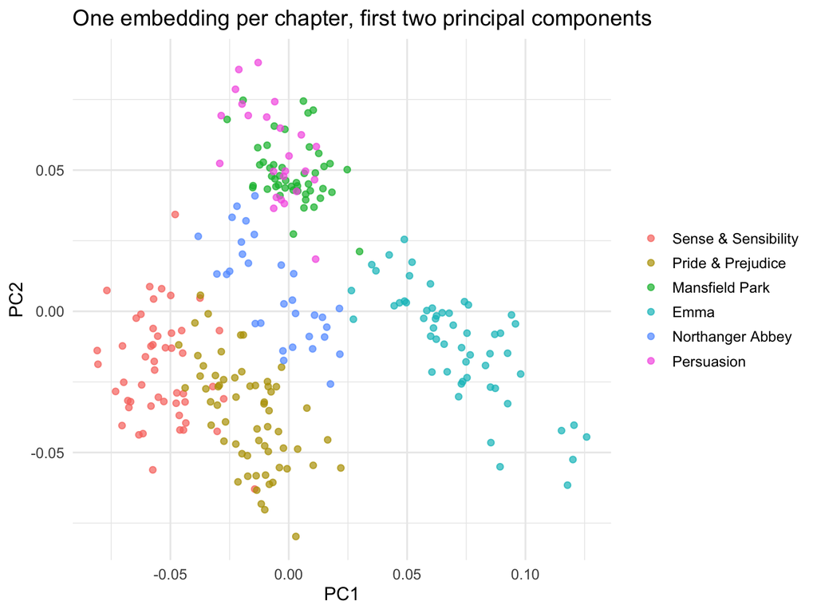

```r
chapters <- austen_books() |>
  group_by(book) |>
  mutate(chapter = cumsum(str_detect(text, regex("^chapter [\\divxlc]+", ignore_case = TRUE)))) |>
  ungroup() |>
  filter(chapter > 0) |>
  unnest_tokens(word, text) |>
  anti_join(stop_words, by = "word") |>
  filter(word %in% rownames(E))

chapter_emb <- chapters |>
  group_by(book, chapter) |>
  group_modify(~ as_tibble(t(colMeans(E[.x$word, , drop = FALSE])))) |>
  ungroup()

pc_ch <- prcomp(chapter_emb |> select(-book, -chapter))
chapter_emb |>
  mutate(PC1 = pc_ch$x[, 1], PC2 = pc_ch$x[, 2]) |>
  ggplot(aes(PC1, PC2, color = book)) +
  geom_point(alpha = 0.7) +
  labs(title = "One embedding per chapter, first two principal components", color = NULL)
```

Chapters from the same book tend to sit together, mostly because each book has its own characters and places. With clinical notes, the same steps give one vector per note that can be fed into a classifier.

## 3.6 The problem: one vector per word

Our embeddings give “cold” the same vector in “the patient has a cold” and “the patient’s hands are cold”. To fix this, each word’s vector needs to depend on the words around it. That is what attention does.

# 4 Attention

## 4.1 Where do $\mathbf{X}$, $\mathbf{W}_Q$, $\mathbf{W}_K$, and $\mathbf{W}_V$ come from?

Attention starts from the embeddings we just built. To process a phrase, look up the embedding of each token and stack them as the rows of a matrix $\mathbf{X}$: one row per token, one column per embedding dimension.

```r
phrase <- c("my", "dear", "sister", "wrote", "a", "letter")
X_demo <- E[phrase, ]
dim(X_demo)    # 6 tokens x 100 embedding dimensions
```

```
[1]   6 100
```

This is the same table `E` as before. (In an LLM this table is the first layer of the network and its numbers are learned.) The problem from the last section is visible here: each row depends only on its own word, not on the words around it.

Attention turns each row of $\mathbf{X}$ into three new vectors, using three weight matrices:

- the **query** $\mathbf{Q} = \mathbf{X}\mathbf{W}_Q$: what this token is looking for,
- the **key** $\mathbf{K} = \mathbf{X}\mathbf{W}_K$: what this token offers to be found by, and
- the **value** $\mathbf{V} = \mathbf{X}\mathbf{W}_V$: what this token passes along.

Each weight matrix is just a table of numbers with one row per embedding dimension and one column per new dimension. Here they are $100 \times 16$ (the 16 is a choice).

```r
set.seed(1)
d_k <- 16
W_Q_demo <- matrix(rnorm(100 * d_k, sd = 0.1), 100, d_k)
W_K_demo <- matrix(rnorm(100 * d_k, sd = 0.1), 100, d_k)
W_V_demo <- matrix(rnorm(100 * d_k, sd = 0.1), 100, d_k)

Q_demo <- X_demo %*% W_Q_demo
K_demo <- X_demo %*% W_K_demo
V_demo <- X_demo %*% W_V_demo
dim(Q_demo)                                  # 6 tokens x 16
```

```
[1]  6 16
```

```r
scores_demo <- Q_demo %*% t(K_demo) / sqrt(d_k)
dim(scores_demo)                             # 6 x 6: one score for every pair of tokens
```

```
[1] 6 6
```

There is a direct link to the last section. There, $\mathbf{w}_a^\top \mathbf{c}_b \approx \text{PPMI}(a, b)$ scored how strongly word $a$ goes with context word $b$. In attention, the score between tokens $i$ and $j$ is $\mathbf{q}_i^\top \mathbf{k}_j$: again a dot product between a “center” vector and a “context” vector. What changes is where the vectors come from and what they are computed for:

|  | Embeddings (last section) | Attention |
| --- | --- | --- |
| Where the numbers come from | Counts, PPMI, SVD | Learned by gradient descent on the prediction loss |
| Score for a pair of words | $\mathbf{w}_a^\top \mathbf{c}_b$, the same in every sentence | $\mathbf{q}_i^\top \mathbf{k}_j$, computed for the tokens in *this* sentence |
| Depends on context? | No: one vector per word | Yes: each token’s output is a weighted average of the other tokens’ values |

## 4.2 Attention by hand

To see what each step does, we shrink the example. We’ll compute one attention layer (Vaswani et al., 2017) for the 4-token phrase “no fever or cough”, with $d = 4$ embedding dimensions instead of 100. Instead of learning $\mathbf{W}_Q, \mathbf{W}_K, \mathbf{W}_V$, we **build the embeddings and the weights by hand**, so each number has a meaning we can follow.

Each token gets a $d = 4$ dimensional embedding, and we give each dimension a meaning: is the word a negation, a symptom, a conjunction, or a respiratory term?

```r
features <- c("negation", "symptom", "conjunction", "respiratory")
d <- 4

X <- rbind(no    = c(1, 0, 0, 0),
           fever = c(0, 1, 0, 0),
           or    = c(0, 0, 1, 0),
           cough = c(0, 1, 0, 1))
colnames(X) <- features
tokens <- rownames(X)
X
```

```
      negation symptom conjunction respiratory
no           1       0           0           0
fever        0       1           0           0
or           0       0           1           0
cough        0       1           0           1
```

We want an attention head that does one job: **a symptom looks for a negation word**. We set up the weights so that

- a symptom’s **query** says “I am looking for a negation” (the symptom feature is sent to the first query dimension),
- a negation word’s **key** says “I am a negation” (the negation feature is sent to the first key dimension), and
- each token’s **value** is just its own features ($\mathbf{W}_V$ is the identity matrix).

We store the token vectors as **rows** of $\mathbf{X}$, so the queries for all tokens at once are $\mathbf{Q} = \mathbf{X}\mathbf{W}_Q$. (The slides write $\mathbf{q}_i = \mathbf{W}_Q \mathbf{x}_i$ for a single column vector; it’s the same calculation.)

```r
W_Q <- matrix(0, d, d, dimnames = list(features, NULL))
W_Q["symptom", 1] <- 3       # symptoms ask: "is there a negation?"

W_K <- matrix(0, d, d, dimnames = list(features, NULL))
W_K["negation", 1] <- 3      # negation words answer: "I am a negation"

W_V <- diag(d)
dimnames(W_V) <- list(features, features)

Q <- X %*% W_Q   # queries: "what am I looking for?"
K <- X %*% W_K   # keys:    "what do I contain?"
V <- X %*% W_V   # values:  "what do I pass on?"
Q
```

```
      [,1] [,2] [,3] [,4]
no       0    0    0    0
fever    3    0    0    0
or       0    0    0    0
cough    3    0    0    0
```

```r
K
```

```
      [,1] [,2] [,3] [,4]
no       3    0    0    0
fever    0    0    0    0
or       0    0    0    0
cough    0    0    0    0
```

Only “fever” and “cough” have a non-zero query, and only “no” has a non-zero key.

**Step 1: scores.** How well does each query match each key? Entry $(i, j)$ is $\mathbf{q}_i^\top \mathbf{k}_j / \sqrt{d}$.

```r
scores <- Q %*% t(K) / sqrt(d)
dimnames(scores) <- list(tokens, tokens)
round(scores, 2)
```

```
       no fever or cough
no    0.0     0  0     0
fever 4.5     0  0     0
or    0.0     0  0     0
cough 4.5     0  0     0
```

The only non-zero scores are a symptom’s query matched with the key of “no”: $3 \times 3 / \sqrt{4} = 4.5$.

**Step 2: causal mask.** When generating text, a token may only look at itself and earlier tokens. Setting the future scores to $-\infty$ makes their weights exactly 0 after the softmax.

```r
scores[upper.tri(scores)] <- -Inf
round(scores, 2)
```

```
       no fever   or cough
no    0.0  -Inf -Inf  -Inf
fever 4.5     0 -Inf  -Inf
or    0.0     0    0  -Inf
cough 4.5     0    0     0
```

**Step 3: softmax of each row.** This is the same softmax as the output layer of a neural network for classification. Each row now sums to 1.

```r
softmax <- function(z) exp(z) / sum(exp(z))

A <- t(apply(scores, 1, softmax))   # apply() returns columns, so transpose back
round(A, 2)
```

```
        no fever   or cough
no    1.00  0.00 0.00  0.00
fever 0.99  0.01 0.00  0.00
or    0.33  0.33 0.33  0.00
cough 0.97  0.01 0.01  0.01
```

```r
rowSums(A)
```

```
   no fever    or cough
    1     1     1     1
```

**Step 4: weighted average of the values.** The new vector for each token is $\mathbf{h}_i = \sum_j a_{ij}\mathbf{v}_j$, or $\mathbf{H} = \mathbf{A}\mathbf{V}$ for all tokens at once.

```r
H <- A %*% V
round(H, 2)
```

```
      negation symptom conjunction respiratory
no        1.00    0.00        0.00        0.00
fever     0.99    0.01        0.00        0.00
or        0.33    0.33        0.33        0.00
cough     0.97    0.02        0.01        0.01
```

`A` tells us *how much* each token borrows from the others; `H` is *what it gets*. To see this, compare `H` with the value vectors:

```r
round(V, 2)
```

```
      negation symptom conjunction respiratory
no           1       0           0           0
fever        0       1           0           0
or           0       0           1           0
cough        0       1           0           1
```

```r
# The new vector for "fever" is a weighted average of two value vectors
A["fever", "no"] * V["no", ] + A["fever", "fever"] * V["fever", ]
```

```
   negation     symptom conjunction respiratory
 0.98901306  0.01098694  0.00000000  0.00000000
```

```r
H["fever", ]
```

```
   negation     symptom conjunction respiratory
 0.98901306  0.01098694  0.00000000  0.00000000
```

Reading the rows of `A`:

- **“no”** is the first word, so it can only look at itself: `H["no", ]` is just `V["no", ]`.
- **“fever”** puts weight 0.99 on “no”, so its new vector is almost entirely the value of “no”. In `H`, the negation column for “fever” is now 0.99.
- **“or”** is not a symptom, so its query is all zeros and every score in its row is 0. With no preference, the softmax gives equal weights (1/3 each), and its new vector is a plain average of “no”, “fever”, and “or”.
- **“cough”** also looks back to “no” (weight 0.97), even though “fever” and “or” are in between. Its negation column in `H` is 0.97.

So the head has done what we built it to do: both symptoms now carry the information that they were negated.

There is one problem: “cough” took almost all of its new vector from “no”, so `H` has nearly lost the fact that “cough” is a respiratory symptom. Transformers fix this with the **“add”** step on the slides (a *residual connection*): the output of attention is added to the original embedding, $\mathbf{X} + \mathbf{H}$.

```r
round(X + H, 2)
```

```
      negation symptom conjunction respiratory
no        2.00    0.00        0.00        0.00
fever     0.99    1.01        0.00        0.00
or        0.33    0.33        1.33        0.00
cough     0.97    1.02        0.01        1.01
```

Now “cough” is roughly (negation, symptom, respiratory): a **negated respiratory symptom**. This is a contextual embedding: the vector for “cough” depends on the words before it. Without “no” in front, the negation column for “cough” would stay at 0.

In a trained model, nobody chooses these weights. They are learned from data, a single head usually mixes several jobs, and the dimensions don’t have names like “negation”. But the calculation is exactly the one above.

Put together, the whole layer is one line of matrix algebra:

$$\text{Attention}(\mathbf{Q}, \mathbf{K}, \mathbf{V}) = \text{softmax}\!\left(\mathbf{Q}\mathbf{K}^\top/\sqrt{d}\right)\mathbf{V}.$$

```r
attention <- function(X, W_Q, W_K, W_V, causal = TRUE) {
  Q <- X %*% W_Q; K <- X %*% W_K; V <- X %*% W_V
  scores <- Q %*% t(K) / sqrt(ncol(K))
  if (causal) scores[upper.tri(scores)] <- -Inf
  A <- t(apply(scores, 1, softmax))
  A %*% V
}

all.equal(attention(X, W_Q, W_K, W_V), H)
```

```
[1] TRUE
```

## 4.3 Attention is a weighted average

Attention is a lot like a kernel smoother or $K$-nearest neighbors: each token’s new value is a weighted average of the others, and the weights come from similarity ($\mathbf{q}_i^\top\mathbf{k}_j$). The difference is that the similarity is **learned**.

Below are the illustrative weights from the slides for “The nurse gave the patient her medication because she was in pain.” These are made-up numbers chosen to show what a trained attention head might do, not output from a real model.

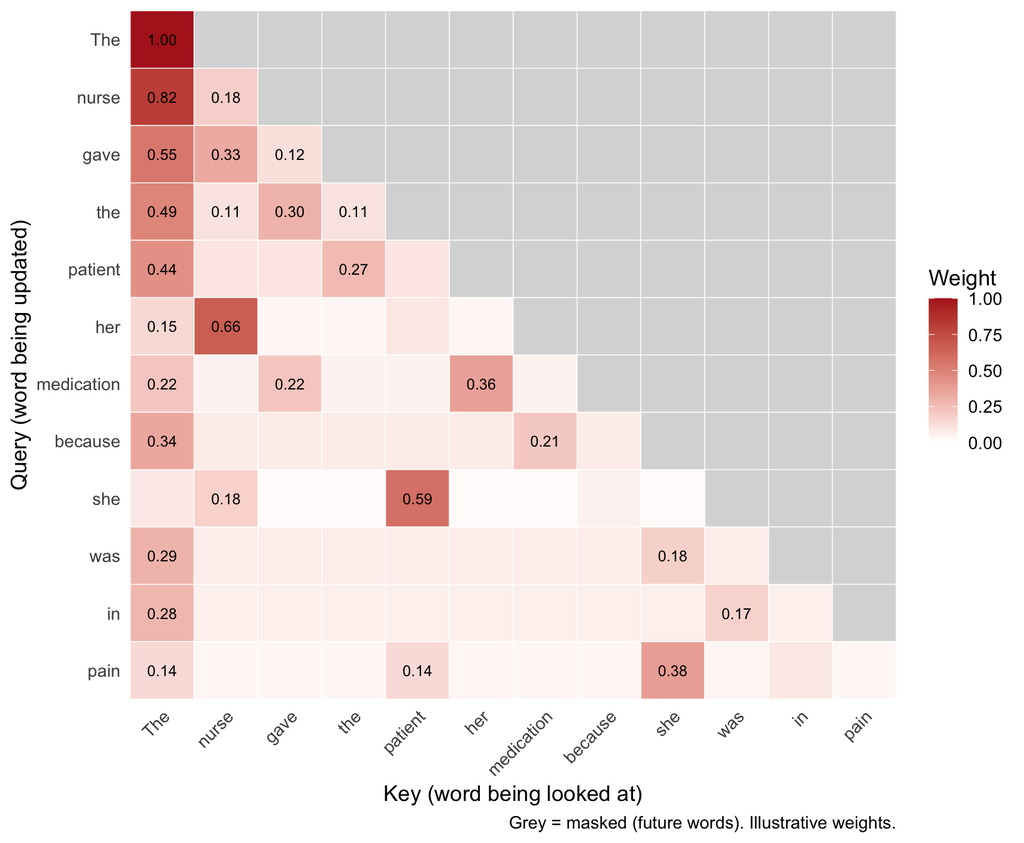

```r
words <- c("The", "nurse", "gave", "the", "patient", "her", "medication",
           "because", "she", "was", "in", "pain")
n <- length(words)

score <- matrix(0, n, n)
score[cbind(2:n, 1:(n - 1))] <- 1          # look at the previous word
score[, 1] <- 1.5                           # spare weight goes to the first token
score[6, 2] <- 3                            # her -> nurse
score[7, c(3, 6)] <- c(1.5, 2)              # medication -> gave, her
score[9, c(2, 5)] <- c(2.2, 3.4)            # she -> nurse, patient
score[12, c(9, 5)] <- c(2.5, 1.5)           # pain -> she, patient
score[upper.tri(score)] <- -Inf             # causal mask
A_she <- t(apply(score, 1, softmax))

expand_grid(i = 1:n, j = 1:n) |>
  mutate(a = A_she[cbind(i, j)], masked = j > i) |>
  ggplot(aes(j, n + 1 - i)) +
  geom_tile(aes(fill = ifelse(masked, NA, a)), color = "white") +
  geom_text(aes(label = ifelse(!masked & a >= 0.1, sprintf("%.2f", a), "")), size = 3.2) +
  scale_fill_gradient(low = "white", high = "firebrick", na.value = "grey85", limits = c(0, 1)) +
  scale_x_continuous(breaks = 1:n, labels = words, expand = c(0, 0)) +
  scale_y_continuous(breaks = n:1, labels = words, expand = c(0, 0)) +
  labs(x = "Key (word being looked at)", y = "Query (word being updated)", fill = "Weight",
       caption = "Grey = masked (future words). Illustrative weights.") +
  theme(axis.text.x = element_text(angle = 45, hjust = 1), panel.grid = element_blank())
```

The row for “she” puts most of its weight on “patient”, some on “nurse”, and a little on everything else.

What about words like “gave” or “patient”, which have nothing in particular to look up? Each row has to sum to 1, so their weight must go *somewhere*. One option is the word itself, but that adds little, because the “add” step (the residual connection, $\mathbf{X} + \mathbf{H}$) already keeps each word’s own vector. Studies of trained models find that heads with nothing to do often put their spare weight on the **first token** (or on punctuation and special tokens), which acts like a “no-op” (Clark et al., 2019; Xiao et al., 2024). This is called an **attention sink**, and it is why the first column of the plot is dark. Our made-up scores have three parts: a few specific links (“she” $\to$ “patient”, “her” $\to$ “nurse”, …), a small score for the previous word, and a default score for the first token.

Notice also that the first few rows are forced by the causal mask: “The” can only look at itself (weight 1), and “nurse” can only choose between “The” and itself.

## 4.4 Why we need positions

Attention by itself doesn’t know the order of the words. To see this, turn off the causal mask, shuffle the tokens, and run attention again. The outputs are the same vectors, just shuffled.

```r
shuffle <- c(4, 2, 3, 1)   # "cough fever or no"
H_full     <- attention(X, W_Q, W_K, W_V, causal = FALSE)
H_shuffled <- attention(X[shuffle, ], W_Q, W_K, W_V, causal = FALSE)

all.equal(H_shuffled, H_full[shuffle, ])
```

```
[1] TRUE
```

So “dog bites man” and “man bites dog” would look the same. The fix is to add a vector that depends on each token’s **position** to its embedding before attention. Now shuffling changes the result:

```r
set.seed(4)
pos <- matrix(rnorm(4 * d, sd = 0.5), nrow = 4)   # one vector per position 1, 2, 3, 4

H_pos          <- attention(X + pos, W_Q, W_K, W_V, causal = FALSE)
H_pos_shuffled <- attention(X[shuffle, ] + pos, W_Q, W_K, W_V, causal = FALSE)

isTRUE(all.equal(H_pos_shuffled, H_pos[shuffle, ]))
```

```
[1] FALSE
```

## 4.5 Multi-head attention

A **multi-head** layer runs several attention operations side by side, each with its own weight matrices, and joins the results. Each head can learn a different kind of relationship (the previous word, pronouns, negation, …).

```r
set.seed(3)
head1 <- attention(X, matrix(rnorm(16), 4), matrix(rnorm(16), 4), matrix(rnorm(16), 4))
head2 <- attention(X, matrix(rnorm(16), 4), matrix(rnorm(16), 4), matrix(rnorm(16), 4))

multi <- cbind(head1, head2)   # in a real model, this is multiplied by one more weight matrix
dim(multi)
```

```
[1] 4 8
```

A Transformer block is this multi-head attention followed by a small feed-forward neural network (like the ones we fit with `torch`), applied to each token. GPT-3 stacks 96 of these blocks, each with 96 heads.

# 5 From scores to the next token

## 5.1 Where do the scores come from?

Here is the whole path so far:

tokens $\rightarrow$ embeddings ($\mathbf{X}$) $\rightarrow$ attention (and add) $\rightarrow$ one vector per token $\rightarrow$ **scores for every word in the vocabulary** $\rightarrow$ softmax $\rightarrow$ next token

The last step before the softmax works like this. Because of the causal mask, the vector for the **last** token in the phrase is the only one that has seen all the others, so the model uses that vector. It compares it with an **output vector** for every word in the vocabulary, using a dot product:

$$z_k = \mathbf{h}_{\text{last}}^\top \mathbf{u}_k,$$

where $\mathbf{h}_{\text{last}}$ is the final vector for the last token and $\mathbf{u}_k$ is the output vector for word $k$. This is the same kind of score as $\mathbf{q}_i^\top\mathbf{k}_j$ in attention and $\mathbf{w}_a^\top\mathbf{c}_b$ in the embeddings section. It is also the “language model as a classifier” idea from the start of the notes: a softmax regression with one class per word in the vocabulary, where the features are $\mathbf{h}_{\text{last}}$. Many models reuse the embedding table for the output vectors.

We can try this with the embeddings we built. Our context vectors `Cv` play the role of the output vectors, and the vector for “sister” plays the role of $\mathbf{h}_{\text{last}}$:

```r
h <- W["sister", ]                      # vector for the last token
z_vocab <- drop(Cv %*% h)               # one score per word: w_sister . c_k
names(z_vocab) <- vocab$word

p_vocab <- softmax(z_vocab)

tibble(token = names(p_vocab), score = z_vocab, prob = p_vocab) |>
  slice_max(prob, n = 6) |>
  kbl2(digits = 3)
```

| token | score | prob |
| --- | --- | --- |
| my | 1.480 | 0.001 |
| her | 1.443 | 0.001 |
| your | 1.352 | 0.001 |
| his | 1.279 | 0.001 |
| sister | 1.249 | 0.001 |
| and | 1.111 | 0.001 |

Each score approximates PPMI(“sister”, $k$) from the embeddings section, so these are the words that appear near “sister”. This is not a real next-word predictor. Our window looks in both directions, and nothing was trained to predict the next word. Two things are missing:

- **Context.** We used the plain vector for “sister”. In a Transformer, $\mathbf{h}_{\text{last}}$ comes out of the attention layers, so the scores depend on every earlier word in the phrase.
- **Training.** In a real LLM, the embedding table, the attention weights, and the output vectors are all learned by minimizing the next-token cross-entropy loss, as in the bigram model.

Temperature and top-$p$ act on these scores, which is what the rest of this section covers.

## 5.2 Temperature

The scores $z_k$ from the step above go through a softmax. **Temperature** $\tau$ divides the scores before the softmax:

$$p_k(\tau) = \frac{\exp(z_k/\tau)}{\sum_j \exp(z_j/\tau)}.$$

Here are illustrative scores for the next token after “Common symptoms of influenza are”.

```r
next_tokens <- c("fever", "cough", "body", "headache", "sore", "chills", "fatigue", "nausea")
z <- c(3.0, 2.4, 1.6, 1.4, 1.0, 0.8, 0.6, -0.5)

softmax_temp <- function(z, tau) softmax(z / tau)

temp_tab <- tibble(token = next_tokens,
                   `tau = 0.3` = softmax_temp(z, 0.3),
                   `tau = 1`   = softmax_temp(z, 1),
                   `tau = 2`   = softmax_temp(z, 2))
temp_tab |> kbl2(digits = 3)
```

| token | tau = 0.3 | tau = 1 | tau = 2 |
| --- | --- | --- | --- |
| fever | 0.868 | 0.423 | 0.259 |
| cough | 0.117 | 0.232 | 0.192 |
| body | 0.008 | 0.104 | 0.129 |
| headache | 0.004 | 0.085 | 0.116 |
| sore | 0.001 | 0.057 | 0.095 |
| chills | 0.001 | 0.047 | 0.086 |
| fatigue | 0.000 | 0.038 | 0.078 |
| nausea | 0.000 | 0.013 | 0.045 |

A low temperature puts almost all the probability on “fever”; a high temperature spreads it out. We can see this by sampling 15 next tokens at each temperature:

```r
set.seed(735)
for (tau in c(0.3, 1, 2)) {
  draws <- sample(next_tokens, 15, replace = TRUE, prob = softmax_temp(z, tau))
  cat("tau =", tau, ":", paste(draws, collapse = ", "), "\n\n")
}
```

```
tau = 0.3 : fever, fever, fever, fever, fever, cough, fever, fever, fever, fever, fever, fever, fever, fever, fever

tau = 1 : fever, chills, fever, headache, cough, headache, chills, chills, body, body, cough, sore, cough, fever, body

tau = 2 : cough, chills, chills, headache, fever, fever, sore, fever, cough, body, sore, cough, fever, headache, fever
```

As $\tau \to 0$, sampling becomes “always pick the most likely token” (greedy). For research use, a low temperature makes results more repeatable, and you should report the setting you used.

## 5.3 Top-$p$ sampling

**Top-$p$** (or “nucleus”) sampling keeps only the most likely tokens whose probabilities add up to at least $p$, and samples from those.

```r
top_p <- function(prob, p = 0.9) {
  o <- order(prob, decreasing = TRUE)
  keep <- o[seq_len(which(cumsum(prob[o]) >= p)[1])]
  out <- rep(0, length(prob))
  out[keep] <- prob[keep] / sum(prob[keep])   # renormalize
  out
}

p1 <- softmax_temp(z, 1)
tibble(token = next_tokens, original = p1, `top-p (p = 0.8)` = top_p(p1, 0.8)) |>
  kbl2(digits = 3)
```

| token | original | top-p (p = 0.8) |
| --- | --- | --- |
| fever | 0.423 | 0.501 |
| cough | 0.232 | 0.275 |
| body | 0.104 | 0.123 |
| headache | 0.085 | 0.101 |
| sore | 0.057 | 0.000 |
| chills | 0.047 | 0.000 |
| fatigue | 0.038 | 0.000 |
| nausea | 0.013 | 0.000 |

The unlikely tokens (“chills”, “fatigue”, “nausea”) can no longer be chosen.

## 5.4 Greedy generation can get stuck

Let’s go back to our bigram model and always pick the most likely next word (temperature $\to 0$):

```r
generate_greedy <- function(start, n_words = 15) {
  out <- start
  for (i in 1:n_words) {
    choices <- bigrams |> filter(prev == tail(out, 1))
    out <- c(out, choices$nxt[which.max(choices$prob)])
  }
  paste(out, collapse = " ")
}

generate_greedy("elizabeth")
```

```
[1] "elizabeth was not be so much as to be so much as to be so much"
```

Greedy generation quickly falls into a loop. Real LLMs see far more context than one word, so this happens much less, but it is one reason chat models use some randomness by default.

# 6 Evaluating an LLM as a classifier

When an LLM labels data for a study (e.g., “is this ED triage note fall-related?”), it is a **measurement instrument**, and we evaluate it like any other classifier: compare its labels with expert labels on a random sample.

The data below are **simulated** to show the steps. We pretend that 600 triage notes were labeled by an expert (the gold standard) and by an LLM, and that about a third of the notes were written in Spanish. In our simulation the LLM is less sensitive on the Spanish notes.

```r
set.seed(735)
n_notes <- 600
notes <- tibble(
  id       = 1:n_notes,
  language = sample(c("English", "Spanish"), n_notes, replace = TRUE, prob = c(2, 1)),
  truth    = rbinom(n_notes, 1, 0.2)
) |>
  mutate(
    sens = ifelse(language == "English", 0.92, 0.75),   # P(LLM says yes | fall)
    spec = 0.95,                                        # P(LLM says no | no fall)
    llm  = ifelse(truth == 1, rbinom(n(), 1, sens), rbinom(n(), 1, 1 - spec)),
    truth = factor(truth, levels = c(1, 0), labels = c("fall", "no fall")),
    llm   = factor(llm,   levels = c(1, 0), labels = c("fall", "no fall"))
  )

conf_mat(notes, truth = truth, estimate = llm)
```

```
          Truth
Prediction fall no fall
   fall     120      26
   no fall   11     443
```

Overall and by subgroup:

```r
llm_metrics <- metric_set(sens, spec, ppv, f_meas)

bind_rows(
  notes |> llm_metrics(truth = truth, estimate = llm) |> mutate(group = "All notes"),
  notes |> group_by(language) |> llm_metrics(truth = truth, estimate = llm) |>
    rename(group = language)
) |>
  select(group, .metric, .estimate) |>
  pivot_wider(names_from = .metric, values_from = .estimate) |>
  kbl2(digits = 2)
```

| group | sens | spec | ppv | f_meas |
| --- | --- | --- | --- | --- |
| All notes | 0.92 | 0.94 | 0.82 | 0.87 |
| English | 0.96 | 0.95 | 0.87 | 0.91 |
| Spanish | 0.77 | 0.93 | 0.67 | 0.72 |

The overall numbers look good, but the LLM misses almost a quarter of the falls in the Spanish notes. Without checking by subgroup we would not see this.

**Measurement error biases downstream estimates.** Suppose the goal is to estimate the share of ED visits that are falls. Using the LLM labels in place of the truth gives

```r
notes |>
  group_by(language) |>
  summarise(true_prevalence = mean(truth == "fall"),
            llm_prevalence  = mean(llm == "fall")) |>
  kbl2(digits = 3)
```

| language | true_prevalence | llm_prevalence |
| --- | --- | --- |
| English | 0.249 | 0.274 |
| Spanish | 0.157 | 0.182 |

**Stability.** If the temperature is above 0, running the same prompt twice can give different labels. A simple check is to run the LLM twice and measure agreement. Here we simulate a second run that disagrees with the first on about 4% of notes:

```r
notes <- notes |>
  mutate(flip = rbinom(n(), 1, 0.04),
         llm_run2 = if_else(flip == 1,
                            if_else(llm == "fall", "no fall", "fall"),
                            as.character(llm)),
         llm_run2 = factor(llm_run2, levels = c("fall", "no fall")))

mean(notes$llm == notes$llm_run2)                    # proportion of notes with the same label
```

```
[1] 0.9616667
```

```r
kap(notes, truth = llm, estimate = llm_run2)         # Cohen's kappa
```

```
# A tibble: 1 × 3
  .metric .estimator .estimate
  <chr>   <chr>          <dbl>
1 kap     binary         0.898
```

# 7 Summary

- A language model is a classifier for the **next token**. A bigram model does this by counting, which fails because most word pairs are never seen and it uses only one word of context.
- **Tokenizers** like BPE split text into subword pieces learned from data.
- **Embeddings** are a form of dimension reduction: similar words get similar vectors. We built them with counts, PPMI, and an SVD.
- **Attention** turns each token’s vector into a weighted average of the other tokens’ vectors, with weights from a softmax. It needs **positional** information to know word order.
- **Temperature** and top-$p$ control how random the generated text is.
- An LLM used to label data is a **measurement instrument**: evaluate it against a gold standard, by subgroup, and check its stability.

## 7.1 Exercises

1. Change the bigram model to a **trigram** model (the next word depends on the previous two words). Generate text from it. Is it better? What share of the word pairs in *Sense and Sensibility* (now word triples) were never seen?
2. Run the BPE code with 15 merges instead of 8. What tokens does it learn? Add the word “slowest” (with a count of 4) to the corpus and repeat.
3. Rebuild the Austen embeddings with a window of 2 words instead of 4 (change `1:4` to `1:2`). How do the nearest neighbors of “sister” and “letter” change?
4. In the “attention by hand” example, change the 3 in `W_Q["symptom", 1] <- 3` to 1, and then to 10, and recompute `A` and `H`. What happens to the attention weights? How is this like changing the temperature?
5. In the simulated evaluation, change the sensitivity for Spanish notes to 0.92. How do the subgroup results and the prevalence table change?

# References

- Clark K, Khandelwal U, Levy O, Manning CD (2019). What does BERT look at? An analysis of BERT’s attention. *Proceedings of the ACL Workshop BlackboxNLP*.
- Kaplan J, et al. (2020). Scaling laws for neural language models. *arXiv:2001.08361*.
- Levy O, Goldberg Y, Dagan I (2015). Improving distributional similarity with lessons learned from word embeddings. *Transactions of the Association for Computational Linguistics*, 3, 211–225.
- Sennrich R, Haddow B, Birch A (2016). Neural machine translation of rare words with subword units. *Proceedings of ACL*.
- Vaswani A, et al. (2017). Attention is all you need. *NeurIPS*.
- Xiao G, Tian Y, Chen B, Han S, Lewis M (2024). Efficient streaming language models with attention sinks. *ICLR*.
- Jurafsky D, Martin JH. *Speech and Language Processing*, 3rd ed. draft. https://web.stanford.edu/~jurafsky/slp3/ (see the chapters on embeddings and Transformers).
- Alammar J. The Illustrated Transformer. https://jalammar.github.io/illustrated-transformer/